# Ecological Archives E095-209-metadata

*Ecological Archives* E095-209-D1

Matt G. Bradford, Helen T. Murphy, Andrew J. Ford, Dominic L. Hogan, Daniel J. Metcalfe. 2014. Long-term stem inventory data from tropical rain forest plots in Australia. *Ecology* 95:2362. http://dx.doi.org/10.1890/14-0458R.1

Introduction

Globally, forests are recognised as valuable for their intrinsic worth, the biodiversity they support, the ecosystem services they provide, their value for timber and non-timber products and the potential that they have for ameliorating the impacts of climate change. However, we still have a limited understanding of their dynamics and capacity to adapt to change; addressing this knowledge gap requires long term monitoring approaches. The data collected from long term permanent plot stem inventories allows assessment of timber productivity, stand structure (e.g., Manokaran and LaFrankie 1990), stand diversity (e.g., Lee et al. 2002), carbon storage (e.g., Baker et al. 2004) and, over time, provides insights into the dynamics of forests (e.g., Lewis et al. 2004).

The CSIRO permanent rainforest plots are located within 60 km of the north Queensland coast between Mackay (21.5ºS, 149ºE) and the Iron Range on Cape York Peninsula (12.5ºS, 143ºE). North-eastern Australia is topographically diverse, and the plots span much of the geographical variation in environmental gradients across the study area. The climate is tropical with mean annual rainfall ranging from 1200 mm to over 8000 mm on the higher coastal ranges. Seventeen of the plots are located within the Wet Tropics Bioregion (sensu Department of Environment 2013) between 19.4ºS, 146.5ºE and 15.7ºS, 145.3ºE. While covering only 0.24% of the Australian continent, the Wet Tropics bioregion contains very high levels of diversity and endemism of flora and fauna (Metcalfe and Ford 2009; Stork et al. 2011; Bradford et al. in press). Continuous areas of rainforest account for approximately 6300 km² of the region (Tracey 1982) and represent by far the largest area of rainforest in Australia. At the northern end of the study area, the rainforests of Cape York Peninsula form a largely discontinuous band that have close affinities to the flora of New Guinea which lies just to the north. At the southern end of the study area, the rainforests of the Mackay area contain floristics elements representing both tropical and sub-tropical rainforest.

Indigenous people have occupied north Queensland rainforests for at least 8000 years (Hill et al. 2011), though traditional use of the area had largely ceased in the second half of the 20th century. Due to the low population density, it is unlikely that the original inhabitants contributed significantly to rainforest dynamics except in small areas, with only very selective timber harvesting, clearing and burning taking place. In contrast, during the 20th century, 50% of the rainforest area in the wet tropical area of North Queensland was cleared (Winter 1987) and a large proportion was selectively logged on at least one occasion. With minor exceptions on two plots, all CSIRO permanent plots were established in unlogged forest. All plots were thereafter protected from selective logging activities. In 1988 almost all of the remaining rainforest area under State Forest and National Park in the state of Queensland, including 16 CSIRO permanent plots, was protected under World Heritage listing as the Wet Tropics of Queensland World Heritage Area. The remaining four plots are protected in National Park or Forest Reserve.

The major drivers of forest dynamics in the study area are non-anthropogenic disturbances, especially cyclones, but including drought, erosion and pathogen outbreaks (see Metcalfe et al. 2008; Metcalfe and Bradford 2008; Murphy et al. 2013). Seventeen of the 20 plots have been impacted by at least one of these disturbances since establishment with cyclones causing major disturbances on 11 plots and minor disturbances on a further four (Table 1).

> Table 1. Summary data for the CSIRO permanent rainforest plots. *C = major cyclone disturbance, c = minor cyclone disturbance, D = drought, P = patch death, E = erosion. Cyclones: Winifred 1986, Aivu 1989, Rona 1999, Ingrid 2005, Monica 2006, Larry 2006, Hamish 2009, Uluia 2010, Yasi 2011.

> | **EP number** | **Plot name** | **First census** | **Last census** | **Number of census'** | **Stems first census (ha<sup>-1</sup>)** | **Stems last census (ha<sup>-1</sup>)** | *Disturbance event |
> | --- | --- | --- | --- | --- | --- | --- | --- |
> | 2 | Downfall Creek | 1971 | 2011 | 16 | 924 | 1012 | C (2006) |
> | 3 | Mount Haig | 1971 | 2011 | 16 | 1004 | 966 | c (2006) |
> | 4 | Pine Creek | 1972 | 2012 | 14 | 972 | 916 | C (1990) |
> | 9 | Robson Creek | 1972 | 2011 | 15 | 882 | 856 | C (2006) |
> | 18 | Mount Lewis | 1973 | 2012 | 15 | 908 | 838 | P(1987-1996) |
> | 19 | Garrawalt | 1975 | 2013 | 13 | 800 | 1032 | P (1978–1989), C(2011) |
> | 29 | Mount Fisher | 1975 | 2011 | 14 | 988 | 842 | C (2006, 2011) |
> | 30 | Agapetes LA | 1976 | 2013 | 12 | 1104 | 1134 |  |
> | 31 | Woopen Creek | 1976 | 2013 | 10 | 476 | 410 | C (1986, 2006), c(2011) |
> | 32 | Mcllwraith Range | 1975 | 2008 | 12 | 894 | 816 | C (2006) |
> | 33 | Curtain Fig | 1976 | 2011 | 13 | 630 | 514 | c (2006), D (1995) |
> | 34 | Russell River | 1976 | 2012 | 12 | 604 | 474 | C (2006) |
> | 35 | Whyanbeel | 1977 | 2012 | 13 | 1002 | 818 | c(1986) |
> | 37 | Eungella | 1977 | 2013 | 12 | 772 | 888 | c (1989, 2009, 2010) |
> | 38 | The Crater | 1977 | 2011 | 13 | 746 | 644 | C (2006) |
> | 40 | Agapetes SA | 1978 | 2013 | 11 | 992 | 848 | D (2006) |
> | 41 | Oliver Creek | 1977 | 2012 | 13 | 790 | 630 |  |
> | 42 | Iron Range | 1977 | 2013 | 12 | 486 | 430 | C (2005), c (2006), E 1979–2013) |
> | 43 | Mount Baldy | 1978 | 2012 | 12 | 778 | 678 | C (2006) |
> | 44 | Fantail LA | 1980 | 2013 | 10 | 878 | 778 |  |

The data collected from the CSIRO permanent rainforest plots has been valuable to date in enabling structural and floristic descriptions of Australian tropical forests, in supplying numerous voucher specimens for herbaria and providing focal areas for intensive ecological studies. With time, the data has given insights into forest dynamics including growth, recruitment and mortality in representative forest types. The plots are now well placed to monitor any effects of a changing climate on species and forest dynamics.

Metadata

Class I. Data set descriptors

**A. Data set identity**: CSIRO permanent rainforest plots, 1971–2013

**B. Data set identification code**: CSIRO_permanent_ plots.zip

**C. Data set description**

**Principal Investigators**:

Matt Bradford, CSIRO Land and Water, Tropical Forest Research Centre, P.O. Box 780 Atherton, 4883, Australia. matt.bradford@csiro.au, +61 740918800

Helen Murphy, CSIRO Land and Water, Tropical Forest Research Centre, P.O. Box 780 Atherton, 4883, Australia. helen.murphy@csiro.au, +61 740918800

Andrew Ford, CSIRO Land and Water, Tropical Forest Research Centre, P.O. Box 780 Atherton, 4883, Australia. andrew.ford@csiro.au, +61 740918800

Daniel J. Metcalfe, CSIRO Land and Water, EcoSciences Precinct, 41 Boggo Road, Dutton Park, 4102, Australia. dan.metcalfe@csiro.au, +61 738335504

**Abstract:** We present repeated stem measurement data from 20 0.5-ha (100 × 50 m) permanent rain forest plots in northern Queensland, Australia from 1971 to 2013. The plots have a rainfall range of 1200 to 3500 mm, represent 11 vegetation types, six parent materials, and range from 15 to 1200 m above sea level. Except for minor disturbances associated with selective logging on two plots, the plots were established in old growth forest and all plots have thereafter been protected. Plots were regularly censused and at each census the diameter at breast height (DBH) of all stems ≥10 cm DBH were recorded. Data is presented for 10998 individual stems with plot stem densities at establishment ranging from 476 to 1104 stems/ha. Due to the wide geographical range of the plots, no species dominate, although the families Lauraceae, Rutaceae, and Myrtaceae contribute a large number of species. Basal area values at establishment ranged from 28.6 to 63.3 m²/ha and showed no trend of increasing or decreasing over time due mainly to regular disturbance and recovery from natural events such as cyclones. In addition to stems ≥10 cm DBH data, we present height data, floristic data from understory stems (≥50 cm height to <10 cm DBH), an auxiliary species list (including vines, epiphytes, ferns, grasses, herbs, and other life forms), and a list of voucher specimens lodged in herbaria. The data collected from the 20 plots provides an insight into the floristics, structure, and long-term forest dynamics of Australian tropical rain forests and allows direct comparisons to be made with long-term monitoring plots at a global scale.

**D. *Key words***: *Australia; biomass; cyclone; disturbance; hurricane; mortality; permanent plot; rain forest; recruitment; stem growth; stem height.*

Class II. Research origin descriptors

**A. Overall project description**

**Identity:** CSIRO permanent rainforest plots, 1971–2013

**Originator:** G. C. Stocker (Commonwealth Forest and Timber Bureau, Atherton, later CSIRO).

**Objective:** To record and analyse patterns of stem growth and stand dynamics in a broad range of permanently reserved plots in rainforest in North Queensland, Australia.

**Abstract:** The objective of the long term plot series was to build a comprehensive database of rainforest stem growth, extending over a useful range of sites and a biologically meaningful span of years. To provide for analysis and interpretation, the growth record needed to include descriptions of forest structure, floristic composition and stand changes in response to environmental disturbance. This required a high standard of repeated mensuration and continuity, in a variety of rainforest sites whose location is definable in terms of major environmental gradients. To investigate the floristic and structural consequences of a given type of disturbance, several strategies were developed; (a) to establish a series of 0.5 ha reference plots where the growth, recruitment and mortality of component species could be monitored for long periods. Where possible, these plots were located in generally representative unlogged forest, (b) to study the reproductive biology and early growth characteristics of the major (ecologically and numerically) species found in the permanent plot series, and (c) to use data from (a) and (b) to develop models which will predict floristic and structural change in different forest types subjected to disturbances varying in nature, frequency and degree.

**Sources of funding:** Commonwealth Forest and Timber Bureau (1971–1978), CSIRO internal funding (1978–1992), Tropical Rainforest Ecology and Management and the Rainforest Cooperative Research Centres (1992–2006), Earthwatch (2006). The most recent censuses have been supported by the Long-Term Ecological Research Network sub facility, part of the Australian Government's Terrestrial Ecosystems Research Network (http://www.tern.org.au/Long-Term-Ecological-Research-Network-LTERN-pg17872.html).

**Background:** In 1971, about 100 years after the first European commercial exploitation of rainforests in North Queensland, work commenced on the first in a series of specifically planned, long term research plots designed to examine natural processes in rainforests rather than responses to, or suitability for, timber extraction. This work was carried out by the Atherton based staff of the Forest and Timber Bureau within the Commonwealth Department of National Development led by Geoff Stocker. Some plots were opportunistically located ahead of logging operations and showed some bias towards commercially attractive species, however, these species are often common and widespread and the plots are considered representative of several widespread forest types. Several such species in the genus *Flindersia* were initially recorded to seedling and sapling stage on eight plots. This work was abandoned in the 1980s and the data is not presented in this data paper.

Subsequent to establishment, CSIRO staff and volunteers based at the Tropical Forest Research Centre in Atherton have maintained the project. In particular, Keith Sanderson (1971–1998) and Matt Bradford (1998–2013) have supervised each census and maintained the data.

**B. Specific subproject description**

**II.B.1. Census of stems ≥10 cm DBH**

**Site description:** The study was conducted in the rainforests of North Queensland, Australia between Mackay 21.5ºS, 149ºE and the Iron Range 12.5ºS, 143ºE. The plots span much of the geographical variation in environmental gradients across the study area and represent eleven moist humid tropical vegetation (Tracey 1982), six parent material types, and range from 15 m to 1200 m asl (Table 2). The climate is tropical with mean annual rainfall ranging from 1200 mm to over 8000 mm on the higher coastal ranges. Seventeen of the plots are located within the Wet Tropics Bioregion which is broadly composed of closed canopy rainforest and open *Eucalyptus* forests and woodlands. Continuous areas of rainforest account for approximately 6300 km² of the region (Tracey 1982) and are found in the wetter and mountainous areas where the rainfall exceeds 1500 mm. Full site descriptions of each plot can be found in Graham (2006).

> Table 2. Some physical and environmental parameters of the CSIRO permanent rainforest plots. Area is slope corrected to represent a projected plan view of 0.5 ha (100 m × 50 m). Temperature and precipitation values are derived from the ANUCLIM model (McMahon et al. 1995) except * which are estimates based on the nearest long term recording station.

> | **EP number** | **Plot name** | **Latitude** | **Longitude** | **Altitude** **(m asl)** | **Area (ha)** | **Annual mean temperature (°C)** | **Annual precipitation (mm)** |
> | --- | --- | --- | --- | --- | --- | --- | --- |
> | 2 | Downfall Creek | -17.14616 | 145.58688 | 720 | 0.5128 | 20.7 | 1403 |
> | 3 | Mount Haig | -17.08783 | 145.59161 | 1120 | 0.5434 | 18.7 | 2884 |
> | 4 | Pine Creek | -16.99486 | 145.83122 | 110 | 0.5096 | 24.9 | 2453 |
> | 9 | Robson Creek | -17.11544 | 145.63272 | 800 | 0.5593 | 20.4 | 1769 |
> | 18 | Mount Lewis | -16.52264 | 145.26656 | 1100 | 0.5098 | 19.2 | 2676 |
> | 19 | Garrawalt | -18.49892 | 145.75628 | 620 | 0.5235 | 21.4 | 1236 |
> | 29 | Mount Fisher | -17.54569 | 145.54811 | 1200 | 0.5237 | 18.3 | 2857 |
> | 30 | Agapetes LA | -16.27767 | 145.07139 | 1060 | 0.5081 | 19.5 | 2597 |
> | 31 | Woopen Creek | -17.52669 | 145.82919 | 80 | 0.5241 | 24.2 | 3365 |
> | 32 | Mcllwraith Range | -13.73922 | 143.34822 | 450 | 0.5038 | n.a. | 2000* |
> | 33 | Curtain Fig | -17.28642 | 145.57183 | 720 | 0.5063 | 20.6 | 1424 |
> | 34 | Russell River | -17.40858 | 145.77078 | 380 | 0.5269 | 22.8 | 3101 |
> | 35 | Whyanbeel | -16.35542 | 145.33667 | 230 | 0.5401 | 24.4 | 2411 |
> | 37 | Eungella | -21.23492 | 148.55153 | 920 | 0.5170 | n.a. | 2400* |
> | 38 | The Crater | -17.35025 | 145.47919 | 1000 | 0.5180 | 19.2 | 1797 |
> | 40 | Agapetes SA | -16.28017 | 145.10231 | 800 | 0.5236 | 20.7 | 2097 |
> | 41 | Oliver Creek | -16.13658 | 145.44139 | 15 | 0.5050 | 25.3 | 3470 |
> | 42 | Iron Range | -12.74061 | 143.25339 | 60 | 0.5093 | n.a. | 2200* |
> | 43 | Mount Baldy | -17.30869 | 145.43725 | 1120 | 0.5716 | 19.1 | 1655 |
> | 44 | Fantail LA | -16.21794 | 145.08522 | 910 | 0.5240 | 20.2 | 2365 |

**Experimental or sampling design:** The 20 CSIRO permanent plots were opportunistically located ahead of logging operations or in areas of no or minor recent disturbance (EP9 and EP38 showed evidence of slight disturbance in a section of the plot due to selective logging at least 20 years prior to establishment). Where possible, plots were located to represent the major forests and geologies of North Queensland. All plots were surveyed to enclose a projected plan view area of 0.5 ha (100 m × 50 m) with plot boundary distances corrected for slope. The resulting plot areas are presented in Table 2. Plot boundaries were surveyed with prismatic compasses, 50 m steel survey band and Abney level. The four plot corners were initially marked with treated wooden pegs and subsequently replaced with steel pickets. All plots were subdivided into 16 subplots (A to P; Fig. 1), each 25 m × 12.5 m with permanent wooden subplot markers. A 20 m buffer area around each plot was established to exclude future human disturbance. A canopy tower was located adjacent to both EP4 and EP33 from establishment until 2005 and focused on canopy sampling and photosynthetic studies. Data from the towers is not included in this data paper, however, publications resulting from data collected are included in the publications and results section. The plots were established between 1971 and 1980 and were initially censused every two years until 1991 (Table 3). Since 1991 census intervals have ranged between 2–15 years.

> Table 3. Census dates for the measurement of stems ≥10 cm DBH on the CSIRO permanent rainforest plots. Note that the dates represent a midpoint: some censuses may have taken more than one day, especially at establishment.

> |  | **EP2** | **EP3** | **EP4** | **EP9** | **EP18** | **EP19** | **EP29** | **EP30** | **EP31** | **EP32** | **EP33** | **EP34** | **EP35** | **EP37** | **EP38** | **EP40** | **EP41** | **EP42** | **EP43** | **EP44** |
> | --- | --- | --- | --- | --- | --- | --- | --- | --- | --- | --- | --- | --- | --- | --- | --- | --- | --- | --- | --- | --- |
> | **1971** | 25/7/71 | 25/10/71 |  |  |  |  |  |  |  |  |  |  |  |  |  |  |  |  |  |  |
> | **1972** |  |  | 10/8/72 | 19/3/72 |  |  |  |  |  |  |  |  |  |  |  |  |  |  |  |  |
> | **1973** | 12/6/73 | 19/9/73 |  |  | 1/9/73 |  |  |  |  |  |  |  |  |  |  |  |  |  |  |  |
> | **1974** |  |  | 13/8/74 | 23/3/74 |  |  |  |  |  |  |  |  |  |  |  |  |  |  |  |  |
> | **1975** | 12/6/75 | 16/9/75 |  |  | 1/10/75 | 5/6/75 | 2/11/75 |  |  | 16/9/75 |  |  |  |  |  |  |  |  |  |  |
> | **1976** |  |  | 6/8/76 | 16/3/76 |  |  |  | 8/6/76 | 13/8/76 |  | 16/3/76 | 13/11/76 |  |  |  |  |  |  |  |  |
> | **1977** | 25/7/77 | 11/10/77 |  |  | 19/9/77 | 18/7/77 | 13/11/77 |  |  | 18/7/77 |  |  | 29/4/77 | 23/6/77 | 5/9/77 |  | 2/11/77 | 17/11/77 |  |  |
> | **1978** |  |  | 2/8/78 | 7/4/78 |  |  |  | 19/6/78 | 2/8/78 |  | 19/3/78 | 18/10/78 |  |  |  | 11/10/78 |  |  | 26/6/78 |  |
> | **1979** | 16/6/79 | 19/9/79 |  |  | 29/10/79 | 30/6/79 | 7/10/79 |  |  | 5/9/79 |  |  | 22/4/79 | 30/6/79 | 23/9/79 |  | 18/10/79 | 5/8/79 |  |  |
> | **1980** |  |  | 28/8/80 | 26/3/80 |  |  |  | 12/6/80 | 28/8/80 |  | 16/3/80 | 23/9/80 |  |  |  | 14/10/80 |  |  | 4/7/80 | 6/11/80 |
> | **1981** | 16/6/81 | 1/9/81 |  |  | 22/10/81 | 23/6/81 | 8/12/81 |  |  | 22/7/81 |  |  | 24/5/81 | 23/6/81 | 23/9/81 |  | 16/12/81 | 22/7/81 |  |  |
> | **1982** |  |  | 24/8/82 | 23/3/82 |  |  |  | 19/6/82 | 8/9/82 |  | 1/3/82 | 18/10/82 |  |  |  | 2/11/82 |  |  | 16/6/82 | 2/11/82 |
> | **1983** | 29/7/83 | 12/9/83 |  |  | 11/10/83 | 19/6/83 | 2/11/83 |  |  | 14/7/83 |  |  | 5/6/83 | 12/6/83 | 4/10/83 |  | 10/11/83 | 11/7/83 |  |  |
> | **1984** |  |  | 10/8/84 | 19/3/84 |  |  |  | 14/10/84 | 14/10/84 |  | 12/3/84 | 1/12/84 |  |  |  | 18/10/84 |  |  | 22/7/84 | 14/10/84 |
> | **1985** | 6/8/85 | 12/9/85 |  |  | 15/9/85 | 5/6/85 | 5/12/85 |  |  | 22/7/85 |  |  | 19/6/85 | 1/6/85 | 12/9/85 |  | 20/11/85 | 22/7/85 |  |  |
> | **1986** |  |  | 28/8/86 | 8/3/86 |  |  |  | 24/11/86 | 1/10/86 |  | 11/4/86 | 13/11/86 |  |  |  | 24/11/86 |  |  | 24/8/86 | 24/11/86 |
> | **1987** | 30/6/87 | 11/10/87 |  |  | 14/7/87 | 1/8/87 | 14/10/87 |  |  | 8/9/87 |  |  | 1/9/87 | 6/8/87 | 11/7/87 |  | 22/10/87 | 8/9/87 |  |  |
> | **1988** |  |  | 28/8/88 | 24/5/88 |  |  |  | 11/10/88 | 4/10/88 |  | 17/5/88 | 13/11/88 |  |  |  | 11/10/88 |  |  | 12/6/88 | 11/10/88 |
> | **1989** | 3/7/89 | 12/9/89 |  |  | 14/7/89 | 20/8/89 | 12/9/89 |  |  |  |  |  | 10/8/89 | 24/8/89 | 25/7/89 |  | 13/8/89 |  |  |  |
> | **1990** |  |  | 22/1/90 | 23/6/90 |  |  |  | 28/8/90 | 4/10/90 | 19/9/90 | 28/5/90 | 25/10/90 |  |  |  | 28/8/90 |  | 19/9/90 | 26/6/90 | 28/8/90 |
> | **1991** | 29/7/91 | 28/8/91 |  |  | 5/9/91 | 23/6/91 | 2/11/91 |  |  |  |  |  | 6/11/91 | 26/6/91 | 13/8/91 |  | 10/11/91 |  |  |  |
> | **1992** |  |  |  |  |  |  |  |  |  |  |  |  |  |  |  |  |  |  |  |  |
> | **1993** |  |  |  |  |  |  |  |  |  |  |  |  |  |  |  |  |  |  |  |  |
> | **1994** |  |  |  |  |  |  |  |  |  |  |  |  |  |  |  |  |  |  |  |  |
> | **1995** | 16/9/95 | 19/9/95 |  | 6/8/95 |  |  | 25/10/95 |  |  |  | 26/6/95 |  | 11/10/95 |  | 22/7/95 |  | 4/10/95 |  | 22/7/95 |  |
> | **1996** |  |  |  |  | 11/1/96 |  |  |  |  |  |  |  |  |  |  |  |  |  |  |  |
> | **1997** |  |  |  |  |  |  |  |  |  |  |  |  |  |  |  |  |  |  |  |  |
> | **1998** | 7/7/98 | 30/6/98 | 17/8/98 | 14/7/98 | 17/11/98 | 1/12/98 | 7/10/98 | 22/10/98 |  | 8/9/98 | 22/7/98 | 10/8/98 | 6/11/98 |  | 24/8/98 | 24/11/98 | 11/10/98 | 12/9/98 | 29/7/98 | 18/10/98 |
> | **1999** |  |  |  |  |  |  |  |  |  |  |  |  |  |  |  |  |  |  |  |  |
> | **2000** |  |  |  |  |  |  |  |  |  |  |  |  |  |  |  |  |  |  |  |  |
> | **2001** |  |  |  |  |  |  |  |  |  |  |  |  |  | 10/8/01 |  |  |  |  |  |  |
> | **2002** | 23/7/02 | 7/11/02 | 20/10/02 | 10/9/02 | 19/10/02 |  | 13/11/02 | 13/1/02 |  | 24/9/02 | 20/12/02 | 13/9/02 | 16/1/02 |  | 25/7/02 | 14/1/02 | 16/8/02 | 26/9/02 | 12/12/02 |  |
> | **2003** |  |  |  |  |  |  |  |  |  |  |  |  |  |  |  |  |  |  |  |  |
> | **2004** |  |  |  |  |  |  |  |  |  |  |  |  |  |  |  |  |  |  |  | 6/10/04 |
> | **2005** |  |  |  |  |  | 30/9/05 |  |  | 3/10/05 |  |  |  |  | 9/8/05 |  |  |  |  |  |  |
> | **2006** | 9/8/06 | 10/8/06 | 23/8/06 | 12/8/06 | 10/8/06 |  | 21/8/06 | 21/8/06 |  | 10/9/06 | 9/8/06 | 20/9/06 | 11/8/06 |  | 13/8/06 | 23/8/06 | 12/8/06 | 12/9/06 | 24/8/06 |  |
> | **2007** |  |  |  |  |  |  |  |  |  |  |  |  |  |  |  |  |  |  |  |  |
> | **2008** |  |  |  |  |  |  |  |  |  | 10/9/08 |  |  |  |  |  |  |  | 12/9/08 |  |  |
> | **2009** |  |  |  |  |  | 10/10/09 |  |  |  |  |  |  |  | 20/8/09 |  |  |  |  |  | 1/10/09 |
> | **2010** |  |  |  |  |  |  |  |  |  |  |  |  |  |  |  |  |  |  |  |  |
> | **2011** | 30/8/11 | 15/9/11 |  | 9/9/11 |  |  | 21/9/11 |  |  |  | 3/10/11 |  |  |  | 27/9/11 |  |  |  |  |  |
> | **2012** |  |  | 14/9/12 |  | 5/9/12 |  |  |  |  |  |  | 17/9/12 | 4/9/12 |  |  |  | 31/8/12 |  | 12/9/12 |  |
> | **2013** |  |  |  |  |  | 14/11/13 |  | 27/9/13 | 19/9/13 |  |  |  |  | 12/11/13 |  | 26/9/13 |  | 10/9/13 |  | 24/9/13 |

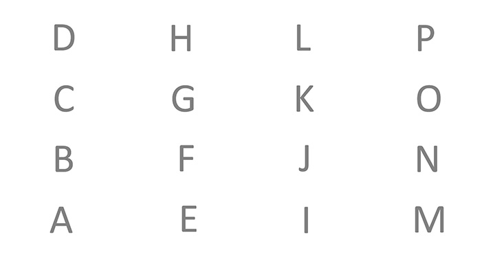

Fig. 1. Subplot layout of the CSIRO permanent plots. Letters (A–P) represent 25 m × 12.5 m subplots.

Rules of measurement are as follows:

1) Comments were recorded for unusual measurements that may affect the way the data is interpreted: 1 = raised or lowered point of measurement, 2 = broken top above POM, 3 = hollow stem, 4 = dead or damaged part of the stem, 5 = DBH estimated, 7 = sick stem, 8 = near dead stem, 9 = leaning >45°.

2) Stem diameters were measured in centimetres at breast height from the ground on the uphill side of the stem. Stems with DBH <10 cm were not included.

3) Stems leaning >45 degrees (comment 9) were measured 1.3 m along the stem along the underside of the stem.

4) Vines were pulled away from the stem or the diameter tape was slipped under the vines before measuring where possible. Where there was a reason why no measurement could be made, a visual estimation of the DBH was made (comment 5). This occurred when a stem had immovable vines, a strangler fig, or large and high buttresses.

5) Stems with a swelling or deformity that precludes taking a normal DBH measurement were measured above or below the deformity. If the deformity continued to <1 m above the ground then the measurement was taken above the deformity.

6) Stems with buttresses were measured at least 1 m above the highest buttress. Smaller specimens of particular species that were known to exhibit buttressing when they grow larger were measured at a higher POM to account for future buttressing. In this case the POM was decided on by the team leader.

7) Where the trunk was irregular, damaged, deformed or fluted at all heights, the POM was taken at 1.3 m. A comment of 3 or 4 was recorded for hollow or damaged stem.

8) Stems that forked above 1.3 m were measured below the fork where the stem was not swollen or deformed. Stems that forked below 1.3 m were measured as separate stems, at or close to 1.3 m.

9) Palms were included if the stem was ≥10 cm DBH below the lowest living leaf base.

10) Lianas were measured 1.3 m along the stem after they left the ground. The height of a liana was recorded as the estimated length of the stem and was generally higher than the host stem. Lianas were mapped where they were considered to originate.

11) The diameter of each individual stem (aerial root) of a strangler fig ≥10 cm DBH was measured separately. Over time when these roots merged with each other or the host stem, then the DBH was estimated (comment 5).

Lianas ≥10 cm DBH were not included in the census at establishment, were included selectively from 1987 onwards. Consequently, the 11 stems listed in Table 4 were most likely present as stems ≥10 cm before they were recorded in the database. All other lianas in the database (8 stems) were included in the database as they were recruited into the ≥10 cm DBH size class.

> Table 4. Large lianas included in the database post establishment. As lianas were not included in the census at establishment, these stems were most likely present as stems ≥10 cm before they were recorded. *N016 is a large liana that became measurable following cyclone damage.

> | **Plot number** | **Stem number** |
> | --- | --- |
> | EP2 | O040 |
> | EP19 | N049 |
> |  | N050 |
> | EP30 | J064 |
> | EP34 | N016* |
> | EP41 | G020 |
> |  | G021 |
> |  | K036 |
> |  | O023 |
> | EP42 | N027 |
> | EP44 | F025 |

The positions of all stems ≥10 cm DBH were mapped to an accuracy of ±0.5 m. The X coordinate was taken as the projected plan distance in metres along the 100 m axis starting at the subplot A–D outside edge of the plot (Fig. 1). The Y coordinate was taken as the projected plan distance in metres along the 50 m axis starting at the subplot A–M outside edge. Where stems originated within 0.5 m of each other or in a multi-stemmed case, the same coordinates were shared within the same plot.

At establishment, the height of each stem ≥10 cm DBH was estimated. Height estimations were taken as the length of the stem from ground to upmost growing tip. Estimations were regularly validated for highly visible stems using the triangulation method (base distance and slope angle) with a clinometer and measuring tape. Height estimations were repeated in 1998 (2001 at ep37; not repeated at ep31) using the same method with the addition of a laser rangefinder (Newcon Optic 1200, Nikon Forestry 550) to aid in base distance, slope angle and direct height estimations where appropriate. Stems recruited at each census were given a height using the same method.

Stems were numbered using an alphanumeric code representing subplot (A to P) and sequential number within that subplot. This code was painted on the stem either below or above the POM line (Fig. 2). Multi-stemmed individuals branching below the POM were numbered by placing a numeral in the 'hundreds' before the stem number. For example: in the same subplot, P005, P105, and P205 are separate trunks of the same individual branching at or below 1.3 m.

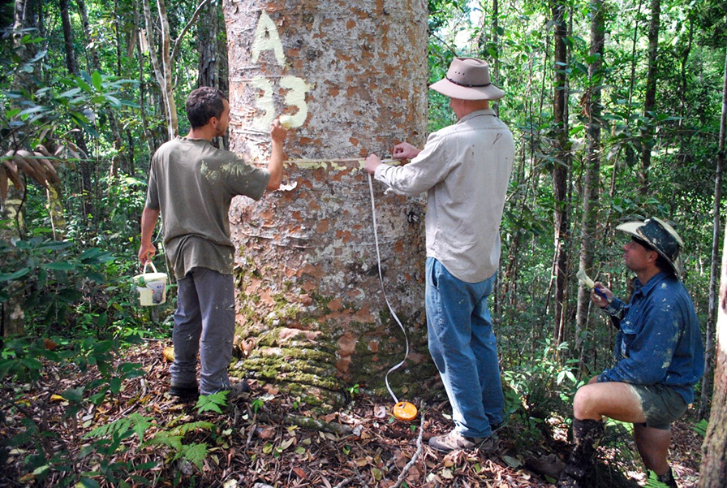

Fig. 2. An example of the point of measurement and stem numbering system on the stem A33, *Agathis robusta* at EP40. Photograph by Dan Metcalfe.

At each census following establishment, new stems recruiting into the ≥10 cm DBH size class were measured, mapped and assigned a height. All stems ≥10 cm DBH that had died since the last census were noted and no attempt was made to assign a cause of death. Stems that were dead or snapped below the painted POM line were considered dead. The nature and extent of major disturbances (e.g., cyclones, erosion) in each plot were noted and mapped.

Initially plant species identification followed the Queensland Herbarium (see Bostock and Holland 2010). For this data paper, these names were matched with the Atlas of Living Australia http://www.ala.org.au/ standards. At establishment, a voucher specimen was collected for a representative of each species at each plot for all stems ≥10 cm DBH. These vouchers were lodged at the Australian Tropical Herbarium (CNS, formerly QRS) and various herbaria around the world. Since establishment, vouchers for any new species have been collected in a semi-formal manner. Wood density values for species represented in the data have been collated from the available literature and from field sampling. These are not presented in the data paper and can be accessed upon application to the principle investigators.

**Project personnel:** Principal investigators, Geoff Stocker, Keith Sanderson, Greg Unwin, Roy Phelps, Neville Starkey, Tony Irvine, Jim O'Farrell, Tom Risley, Don Fitzsimon, Ron Knowlton.

**II.B.2. Survey of understory stems ≥50 cm in height to <10 cm DBH**

**Site description:** same as II.B.1

**Experimental or sampling design:** Plot design and establishment the same as II.B.1.

**Research methods:** The floristics of all understory woody tree and shrub species was assessed for all plots at establishment. Within each of the 16 subplots, the presence or absence of each species was recorded in two size classes; (1) individuals ≥ 50 cm to 3 m in height and (2) individuals >3 m in height and <10 cm DBH. A voucher specimen was collected for a representative of each species not present as a stem ≥10 cm DBH on each plot. These vouchers were lodged at CNS and various herbaria around the world. All plots are progressively being re-assessed and vouchers for any new species are collected in a semi-formal manner. Only data collected at establishment is presented in this data paper and subsequent data can be accessed upon application to the principle investigators.

**Project personnel:** Principal investigators, Bernie Hyland, Tony Irvine, Keith Sanderson, Greg Unwin.

**II.B.3. Survey of auxiliary species**

**Site description:** same as II.B.1

**Experimental or sampling design:** Plot design and establishment the same as II.B.1.

**Research method:** A species list of plants not recorded as stems ≥10 cm DBH or as an understory woody tree or shrub was made for each plot at establishment. Life forms included climber, club moss, cycad, epiphyte, fern, grass, herb, lily, palm, pandan, sedge and vine. Voucher specimens were collected where feasible. These vouchers were lodged at CNS and various herbaria around the world.

**Project personnel:** Principal investigators, Keith Sanderson, Tony Irvine, Greg Unwin.

Class III. Data set status and accessibility

**A. Status**

**Latest update:** December 2013

**Latest Archive date:** December 2013

**Metadata status:** Metadata are complete and are stored with the data.

**Data verification:** Stem DBH values were compared to previous census values as they were collected in the field and following data entry to ensure consistency. Large positive or negative DBH changes that could not be explained by collection or entry errors were flagged to be checked at the next census. Species identifications were originally verified by CSIRO botanists Tony Irvine and Bernie Hyland. More recent identifications were carried out, or verified, by CSIRO botanist Andrew Ford.

**B. Accessibility**

**Storage location and medium:** All digital data and metadata are updated directly to, and stored on, a CSIRO server. Original hard copies of field data are stored in the fireproof room at CSIRO, Atherton.

**Contact persons:**

Matt Bradford, CSIRO Land and Water, Tropical Forest Research Centre, P.O. Box 780 Atherton, 4883, Australia. matt.bradford@csiro.au

Daniel J. Metcalfe, CSIRO Land and Water, EcoSciences Precinct, 41 Boggo Road, Dutton Park, 4102, Australia. dan.metcalfe@csiro.au

**Copyright restrictions:** None.

**Proprietary restrictions:** These data are freely available for non-commercial scientific use (Creative Commons Attribution 3.0 Unported (CC BY 3.0) https://creativecommons.org/licenses/by/3.0/). We encourage researchers to contact us with ideas and proposals for collaborative research projects that utilize these data and to access further data. Investigators should cite this paper if any of its data is used in publications. Investigators should include an acknowledgment of CSIRO Ecosystem Sciences in oral presentations. A suggested acknowledgment is: *We acknowledge that this data is the long term work of CSIRO staff*. Prospective investigators should inform the principle investigators of intent to use the data in publications and provide each of the principle investigators with a copy of any publication resulting from their research project.

While substantial efforts have been made to ensure the accuracy of the data, complete accuracy of data sets cannot be guaranteed. The principal investigators encourage you to contact them with questions or concerns regarding the intended use and appropriate analyses for their data sets.

**Costs:** None.

Class IV. Data structural descriptors

**Class IV. Data Structural Descriptors**

Data set is downloadable as a single archive, CSIRO_permanent_ plots.zip. This file contains a folder named "data" containing 4 data files as detailed below, each in comma separated values formats (.csv). The zip file also contains four text files containing SHA-1 checksums of the data files, and other information conforming to the BagIt file packaging format, version 0.96, developed by the California Digital Library and the Library of Congress (http://tools.ietf.org/pdf/draft-kunze-bagit-09.pdf).

**IV.A.1. CSIRO_PermanentPlots_TreeMeasurementData.csv**

**A. Data set file**

**Identity:** CSIRO_PermanentPlots_TreeMeasurementData.csv

**Size:** 26,624 KB, 17 columns with an initial header row and 109733 records

**Format and storage mode:** ASCII text file, comma separated values, Windows format line breaks (i.e., carriage-return plus line-feed).

**Header information:** Each record represents the data for one stem for a particular year shown in the variable 'year'. Further variable descriptions are provided below in section 'Definition of variable codes'. Headers describe the content of each column and are: epNumber, stemNumber, family, genus, taxon, taxonAuth, ALA_APNI_Taxon_LSID, ALA_APNI_Taxon_URI, wetTropicsEndemic, coordinates_x_metres, coordinates_y_metres, year, dbh_centimetres, comment, establishmentHeight_metres, height_metres, status.

**Special characters/fields:** see below: Definition of variable codes

**Authentication procedures:** SHA-1 checksum: d7890efcf49a89eda55394981bafb14cddd9e4f6

SHA-1 checksums for all data files are listed in the file "manifest-sha1.txt".

**B. Variable information**

Column order in data table ascends (left to right) A–Q.

| **Column Letter Order** | **Variable Identity** | **Variable Definition** | **Storage Type** | **Range / length** | **Missing value codes** |
| --- | --- | --- | --- | --- | --- |
| A | epNumber | CSIRO experimental plot number | Character | 4 characters | N/A |
| B | stemNumber | Alphanumeric character assigned to each stem | Character | 4 characters | N/A |
| C | family | Taxonomic family | Character | 18 characters | Null |
| D | genus | Taxonomic genus | Character | 16 characters | Null |
| E | taxon | Full taxonomic name | Character | 62 characters | Null |
| F | taxonAuth | Full taxonomic name with author | Character | 110 characters | Null |
| G | ALA_APNI_Taxon_LSID | Life Science Identifier (LSID) sourced from the Australian Plant Name Index | Character | 46 characters | Null |
| H | ALA_APNI_Taxon_URI | Australian Plant Name Index URI | Character | 44 characters | Null |
| I | wetTropicsEndemic | Endemic to the Wet Tropic Bioregion of Australia | Boolean | 0-1 | Null |
| J | coordinates_x_metres | Stem position along the 100 m axis | Floating point | 0-99.5; 4 characters | Null |
| K | coordinates_y_metres | Stem position along the 50 m axis | Floating point | 0-50.0; 4 characters | Null |
| L | year | Year of census | Integer | 1971-2013; 4 characters | N/A |
| M | dbh_centimetres | Diameter of the stem (cm) | Floating point | 8.0-204.0; 5 characters | Null |
| N | comment | Comment on the health of the stem or status of the measurement | Integer | 1-9; 1 character | Null |
| O | establishmentHeight_metres | Stem height at establishment | Integer | 2-50; 2 characters | Null |
| P | height_meters | Height of any stem (m) estimated post-establishment | Integer | 1-80; 2 characters | Null |
| Q | status | Dead or Alive at the census shown in variable 'year' | Character | 5 characters | N/A |

**Definition of variable codes:** Descriptions of variable codes are given for those variables needing additional explanation beyond that provided in the data table above.

*epNumber*. CSIRO experimental plot number ranging from ep2 to ep44.

*stemNumber*. An alphanumeric number that is unique to a stem within a plot.

*family*. The taxonomic family name following the Atlas of Living Australia http://www.ala.org.au/. In records where this value is null, this indicates that the taxon of the stem has not been determined.

*genus*. The taxonomic genus name following the Atlas of Living Australia http://www.ala.org.au/. In records where this value is null, this indicates that the taxon of the stem has not been determined.

*taxon*. The species' latin name following Atlas of Living Australia http://www.ala.org.au/. In records where this value is null, this indicates that the taxon of the stem has not been determined. Where no match was found with the Atlas of Living Australia database, the name in taxonAuth either (1) remained the same as described by Queensland Herbarium (see Bostock and Holland 2010) or (2) remained a local assigned name.

*taxonAuth*. The species' latin name with author following Atlas of Living Australia http://www.ala.org.au/.

*ALA_APNI_Taxon_LSID*. The "Life Science Identifier" for the species from the Australian Plant Name Index (IBIS database, Centre for Australian National Biodiversity Research, Australian Government, Canberra http://www.anbg.gov.au/apni/, sourced from the Atlas of Living Australia http://www.ala.org.au. In records where this value is null, this indicates that either; no match was found for the value in "taxonAuth" with a name from the "apni.taxon" collection in the Atlas of Living Australia; or the taxon of the stem has not been determined. The APNI data used was obtained through the Atlas of Living Australia National Species List Linked Data Services available at http://biodiversity.org.au, and is used under a Creative Commons Attribution 3.0 license http://creativecommons.org/licenses/by/3.0/.

*ALA_APNI_Taxon_URI.* A URI for the "Taxon Concept" referred to in the ALA_APNI_Taxon_LSID column.

*year*. See Table 3 for actual stem census dates for each plot.

*dbh_centimetres*. The DBH (1.3 m) of stems ≥10 cm DBH in the plot confines. See research methods for a full explanation.

*comment*. Comments are recorded for unusual measurements that may affect the way the data is interpreted. See research methods for a full explanation.

*establishmentHeight_metres.* The height estimated for each stem ≥10 cm DBH when the particular plot was first established. See Table 3 for establishment dates. Stem heights estimated at later dates or when a stem is recruited into the ≥10 cm DBH size are recorded in the variable code height_metres.

*height_metres*. The height of any stem recruited since establishment, or the height estimated in the second major height census in 1998 (2001 for ep37). In records where this value is null, this indicates that the stem is not new at the year specified in variable 'year' or was not a stem ≥10 cm DBH in 1998 (2001 for ep37).

*status*. Dead or alive for the year given in the variable 'year'. A record showing dead will have a null value in the dbh_centimetres column.

**C. Data Anomalies**

A small number of stems have a DBH <10 cm. In these cases the stem has legitimately shrunk below 10 cm DBH or the stem was damaged in some way resulting in a measurement <10 cm DBH. These stems will continue to be measured.

Repeated stem height estimates are not presented for EP31. Estimates were not made during the 2005 census, and in 2006 a severe cyclone passed over the plot causing considerable structural damage resulting in misleading height estimates.

**IV.A.2. CSIRO_PermanentPlots_UnderstoryData.csv**

**A. Data set files**

**Identity:** CSIRO_PermanentPlots_UnderstoryData.csv

**Size:** 6,338 KB, 10 columns with an initial header row and 30976 records

**Format and storage mode:** ASCII text file, comma separated values, Windows format line breaks (i.e., carriage-return plus line-feed).

**Header information:** Each record represents the data for a species in the understory (≥50 cm in height and <10 cm DBH) in a particular plot and subplot and the presence or absence in two size classes (≥50 cm in height to 3 m in height, and >3 m in height to <10 cm DBH). Further variable descriptions are provided below in section 'Definition of variable codes'. Headers describe the content of each column and are: epNumber, subplot, date, family, genus, taxon, taxonAuth, ALA_APNI_Taxon_LSID, ALA_APNI_Taxon_URI, value.

**Special characters/fields:** see below: Definition of variable codes

**Authentication procedures:** SHA-1 checksum: cfe27411455d1221202c208c25f19bf2b5a6fdb8

SHA-1 checksums for all data files are listed in the file "manifest-sha1.txt"

**B. Variable information**

Header information: Column order in data table ascends (left to right) A–J.

| **Column Letter Order** | **Variable Name** | **Variable Definition** | **Storage Type** | **Range / length** | **Missing value codes** |
| --- | --- | --- | --- | --- | --- |
| A | epNumber | CSIRO experimental plot number | Character | 4 characters | N/A |
| B | subplot | subplot | Character | A to P; 1 character | N/A |
| C | date | Month and year of the survey | Character | June 1971-November 1980; format "mmm-yyyy", 8 characters | N/A |
| D | family | Taxonomic family | Character | 18 characters | Null |
| E | genus | Taxonomic genus | Character | 16 characters | Null |
| F | taxon | Full taxonomic name | Character | 57 characters | Null |
| G | taxonAuth | Full taxonomic name with author | Character | 97 characters | Null |
| H | ALA_APNI_Taxon_LSID | Life Science Identifier (LSID) sourced from the Australian Plant Name Index | Character | 46 characters | Null |
| I | ALA_APNI_Taxon_URI | Australian Plant Name Index URI | Character | 44 characters | Null |
| J | value | Presence or absence in two size classes | Integer | 0-3; 1 character | Null |

**Definition of variable codes:** Descriptions of variable codes are given for those variables needing additional explanation beyond that provided in the data table above.

*subplot.* One of 16, 25 m × 12.5 m subplots as described in research methods.

*date.* Month and year that the understorey survey was undertaken. In some cases the understory inventory was undertaken at a different time as the ≥10 cm DBH stem census (Table 3).

*value*. A value of 1, 2, or 3 representing the presence or absence of stems in two size classes as described in research methods.

**IV.A.3. CSIRO_PermanentPlots_AuxiliaryData.csv**

**A. Data set files**

**Identity:** CSIRO_PermanentPlots_AuxiliaryData.csv

**Size:** 108 KB, 8 columns with an initial header row and 560 records

**Format and storage mode:** ASCII text file, comma separated values, Windows format line breaks (i.e., carriage-return plus line-feed).

**Header information:** Each record represents presence data for species on each plot not recorded as a stem ≥10 cm DBH or understory individuals. Further variable descriptions are provided below in section 'Definition of variable codes'. Headers describe the content of each column and are: epNumber, family, genus, taxon, taxonAuthor, ALA_APNI_Taxon_LSID, ALA_APNI_Taxon_URI, classification.

**Special characters/fields:** see below: Definition of variable codes

**Authentication procedures:** SHA-1 checksum: a0012fb3cd17c23ea6b14c8a0130e5d7f51eef68

SHA-1 checksums for all data files are listed in the file "manifest-sha1.txt"

**B. Variable information**

Header information: Column order in data table ascends (left to right) A–H.

| **Column Letter Order** | **Variable Name** | **Variable Definition** | **Storage Type** | **Range / length** | **Missing value codes** |  |
| --- | --- | --- | --- | --- | --- | --- |
| A | epNumber | CSIRO experimental plot number | Character | 4 characters | N/A |  |
| B | family | Taxonomic family | Character | 17 characters | Null |  |
| C | genus | Taxonomic genus | Character | 15 characters | Null |  |
| D | taxon | Full taxonomic name | Character | 41 characters | Null |  |
| E | taxonAuth | Full taxonomic name with author | Character | 101 characters | Null |  |
| F | ALA_APNI_Taxon_LSID | Life Science Identifier (LSID) sourced from the Australian Plant Name Index | Character | 46 characters | Null |  |
| G | ALA_APNI_Taxon_URI |  | Australian Plant Name Index URI | Character | 44 characters | Null |
| H | Classification |  | Broad plant habit | Character | 9 characters | N/A |

**Definition of variable codes:** Descriptions of variable codes are given for those variables needing additional explanation beyond that provided in their respective data tables.

*classification*. Belonging to the broad plant habit of climber, club moss, cycad, epiphyte, fern, grass, herb, lily, palm, herb, pandan, sedge, vine.

**C. Data Anomalies**

The accumulation of species from data sets IV.A.1-3 do not comprise a comprehensive list of vascular species on the plots. Seasonal and annual species, and those in the canopy, may have been overlooked.

**IV.A.4. CSIRO_PermanentPlots_VoucherData.csv**

**A. Data set files**

**Identity:** CSIRO_PermanentPlots_VoucherData.csv

**Size:** 423 KB, 9 columns with an initial header row and 2008 records

**Format and storage mode:** ASCII text file, comma separated values, Windows format line breaks (i.e., carriage-return plus line-feed).

**Header information:** Each record represents a voucher specimen for a species represented either by a stem ≥10 cm DBH, an understory species, or and auxiliary species. Headers describe the content of each column and are: epNumber, family, genus, taxon, taxonAuth, ALA_APNI_Taxon_LSID, ALA_APNI_Taxon_URI, collector, voucher number.

**Special characters/fields:** none.

**Authentication procedures:** SHA-1 checksum: 67b11e1f3baea4ae19bdc2b734f5da0ce856c052

SHA-1 checksums for all data files are listed in the file "manifest-sha1.txt"

**B. Variable information**

Header information: Column order in data table ascends (left to right) A–I.

| **Column Letter Order** | **Variable Name** | **Variable Definition** | **Storage Type** | **Range / length** | **Missing value codes** |
| --- | --- | --- | --- | --- | --- |
| A | epNumber | CSIRO experimental plot number | Character | 4 characters | N/A |
| B | family | taxonomic family | Character | 18characters | Null |
| C | genus | Taxonomic genus | Character | 16 characters | Null |
| D | taxon | Full taxonomic name | Character | 57characters | Null |
| E | taxonAuth | Full taxonomic name with author | Character | 97characters | Null |
| F | ALA_APNI_Taxon_LSID | Life Science Identifier (LSID) sourced from the Australian Plant Name Index | Character | 46 characters | Null |
| G | ALA_APNI_Taxon_URI | Australian Plant Name Index URI | Character | 44 characters | Null |
| H | collector | Person who collected and lodged the voucher specimen | Character | 13 characters | Null |
| I | voucher number | Herbarium voucher number of the collected specimen | Character | 5 characters | Null |

Class V. Supplemental descriptors

**Related material:** Comprehensive descriptions of all plots including auxiliary structural and edaphic information can be found in Graham (2006).

**Archiving:** All digital data and metadata are updated directly to, and stored on a CSIRO server. Original hard copies of field data are stored at CSIRO, Atherton. The CSIRO permanent plot data is stored on the CSIRO Data Access Portal available as: Matt Bradford; Helen Murphy; Andrew Ford; Dominic Hogan; Dan Metcalfe (2014): CSIRO Permanent Rainforest Plots of North Queensland. v2. CSIRO. Data Collection. 10.4225/08/53C4CC1D94DA0 http://dx.doi.org/10.4225/08/53C4CC1D94DA0

**Redundant archival sites:** N/A

**Publications and results:** The following publications relate directly to the data set, contextually use it, or have used the CSIRO permanent rainforest plots as a study site.

Armstrong, J. E. and A. K. Irvine. 1989. Floral biology of *Myristica insipida* (Myristicaceae). A distinctive beetle pollination syndrome. American Journal of Botany 76:86–94.

Armstrong, J. E. and A. K. Irvine. 1989. Flower, sex ratios, pollen-ovule ratios, fruit set and reproductive effort of a dioecious tree. *Myristica insipida* (Myristicaceae) in two different rainforest communities. American Journal of Botany 76:74–85.

Armstrong, J. E. and A. K. Irvine. 1990. Functions of staminodia in a beetle-pollinated flower of *Eupomatia laurina.* Biotropica 22:429-431.

Asner, G. P., R. E. Martin, A. J. Ford, D. J. Metcalfe, and M. Liddell. 2009. Leaf chemical and spectral diversity in Australian tropical forests. Ecological Applications 19:236–253.

Banin, L., T. R. Feldpausch, O. L. Phillips, T. R. Baker, J. Lloyd, K. Affum-Baffoe, E. J. M. M. Arets, N. J. Berry, M. Bradford, R. J. W. Brienen, S. Davies, M. Drescher, N. Higuchi, D. W. Hilbert, A. Hladik, Y. Iida, K. Abu Salim, A. R. Kassim, D. A. King, G. Lopez-Gonzalez, D. Metcalfe, R. Nilus, K. S. H. Peh, J. M. Reitsma, B. Sonke, H. Taedoumg, S. Tan, L. White, H. Woll, and S. L. Lewis. 2012. What controls tropical forest architecture? Testing environmental, structural and floristic drivers. Global Ecology and Biogeography 21:1179–1190.

Beadle, N. C. W. 1981. The vegetation of Australia. Cambridge University Press, Cambridge, U.K.

Bradford, M. G., D. J. Metcalfe, A. J. Ford, M. J. Liddell, and A. T. McKeown. (in press) Floristics, stand structure and above ground biomass of a 25 ha rainforest plot in the Wet Tropics of Australia. Journal of Tropical Forest Science 00:000–000.

Cooper, W. E. 2013. A taxonomic revision of *Garcinia* L. (Clusiaceae) in Australia, including four new species from tropical Queensland. Austrobaileya 9:1–29.

Doley, D., G. L. Unwin, and D. J. Yates. 1988. Spatial and temporal distribution of photosynthesis and transpiration by single leaves in a rainforest tree, *Argyrodendron peralatu**m*. Australian Journal of Plant Physiology 15:317–326.

Doley, D., D. J. Yates, and G. L. Unwin. 1987. Photosynthesis in an Australian rainforest tree, *Argyrodendron peralatu*m, during the rapid development and relief of water deficits in the dry season. Oecologia 74:441–449.

Grubb P. J., and D. J. Metcalfe. 1996. Adaption and inertia in the Australian tropical lowland rain-forest flora: contradictory trends in intergeneric and intrageneric comparisons of seed size in relation to light demand. Functional Ecology 10:512–520.

Grubb, P. J., D. J. Metcalfe, E. A. A. Grubb, and G. D. Jones. 1998. Nitrogen-richness and protection of seeds in Australian tropical rainforest: a test of plant defence theory. Oikos 82:467–482.

Heinrich, I., K. Weidner, G. Helle, H. Vos, and J. C. G.Banks. 2008. Hydroclimatic variation in far north Queensland since 1860 inferred from tree rings. Palaeogeography, Palaeoclimatology, Palaeoecology 270:116–127.

Herwitz, S. R. 1982. Tropical rainforest influences on rainwater flux. PhD Thesis, Australian National University.

Herwitz, S. R., R. E. Slye, and S. M. Turton. 1998. Co-registered aerial stereopairs from low-flying aircraft for the analysis of long-term tropical rainforest canopy dynamics. Photogrammetric Engineering and Remote Sensing 64:387–406.

Herwitz, S. R., R. E. Slye, and S. M. Turton. 2000. Long-term survivorship and crown area dynamics of tropical rain forest canopy trees. Ecology 81:585–597.

Ford, A. J., and D. A. Halford. 2006. *Gynochthodes oresbia* Halford and A.J.Ford, (Rubiaceae), a new and cryptic species from north-east Queensland. Austrobaileya 7:357–364.

Feldpausch, T. R., L. Banin, O. L. Phillips, T. R. Baker, S. L. Lewis, C. A. Quesada, K. Affum-Baffoe, E. J. M. M. Arets, N. J. Berry, M. Bird, E. S. Brondizio, P. de Camargo, J. Chave, G. Djagbletey, T. F. Domingues, M. Drescher, P. M. Fearnside, M. B. Franca, N. M. Fyllas, G. Lopez-Gonzalez, A. Hladik, N. Higuchi, M. O. Hunter, Y. Iida, K. A. Salim, A. R. Kassim, M. Keller, J. Kemp, D. A. King, J. C. Lovett, B. S. Marimon, B. H. Marimon, E. Lenza, A. R. Marshall, D. J. Metcalfe, E. T. A. Mitchard, E. F. Moran, B. W. Nelson, R. Nilus, E. M. Nogueira, M. Palace, S. Patino, K. S. H. Peh, M. T. Raventos, J. M. Reitsma, G. Saiz, F. Schrodt, B. Sonke, H. E. Taedoumg, S. Tan, L. White, H. Woll, and J. Lloyd. 2011. Height-diameter allometry of tropical forest trees. Biogeosciences 8: 1081–1106.

Feldpausch, T. R., J. Lloyd, S. L. Lewis, R. J. W. Brienen, M. Gloor, A. Monteagudo Mendoza, G. Lopez-Gonzalez, L. Banin, K. Abu Salim, K. Affum-Baffoe, M. Alexiades, S. Almeida, I. Amaral, A. Andrade, L. E. O. C. Aragao, A. Araujo Murakami, E. J. M. M. Arets, L. Arroyo, G. A. Aymard, T. R. Baker, O. S. Banki, N. J. Berry, N. Cardozo, J. Chave, J. A. Comiskey, E. Alvarez, A. de Oliveira, A. Di Fiore, G. Djagbletey, T. F. Domingues, T. L. Erwin, P. M. Fearnside, M. B. Franca, M. A. Freitas, N. Higuchi, E. Honorio, Y. Iida, E. Jimenez, A. R. Kassim, T. J. Killeen, W. F. Laurance, J. C. Lovett, Y. Malhi, B. S. Marimon, B. H. Marimon-Junior, E. Lenza, A. R. Marshall, C. Mendoza, D. J. Metcalfe, E. T. A Mitchard, D. A. Neill, B. W. Nelson, R. Nilus, E. M. Nogueira, A. Parada, K. S. H. Peh, A. Pena Cruz, M. C. Penuela, N. C. A. Pitman, A. Prieto, C. A. Quesada, F. Ramirez, H. Ramirez-Angulo, J. M. Reitsma, A. Rudas, G. Saiz, R. P. Salomao, M. Schwarz, N. Silva, J. E. Silva-Espejo, M. Silveira, B. Sonke, J. Stropp, H. E. Taedoumg, S. Tan, H. ter Steege, J. Terborgh, M. Torello-Raventos, G. M. F. van der Heijden, R. Vasquez, E. Vilanova, V. A. Vos, L. White, S. Willcock, H. Woell, and O. L. Phillips. 2012. Tree height integrated into pantropical forest biomass estimates. Biogeosciences 9:3381–3403.

Graham, A. 2006. The CSIRO rainforest plots of north Queensland: Site, structural, floristic and edaphic descriptions. Cooperative Research Centre for Tropical Rainforest Ecology and Management, Cairns, Australia.

House, S. M. 1989. Pollen movement to flowering canopies of pistillate individuals of three rainforest tree species in tropical Australia. Australian Journal of Ecology 14:77–94.

House, S. M. 1992. Population density and fruit set in three dioecious tree species in Australian tropical rainforest. Journal of Ecology 80:57–69.

House, S. M. 1993. Pollination success in a population of dioecious rainforest trees. Oecologia 96:555–561.

Irvine, A. K., and J. E. Armstrong. 1988. Beetle pollination in Australian tropical rainforests. Proceedings of the Ecological Society of Australia 15:107–113.

Irvine, A. K., and J. E. Armstrong. 1990. Beetle pollination in tropical forests of Australia. Pp. 135–149 *in* Bawa, K. S., and M. Hadley, Editors. Reproductive Ecology of Tropical Forest Plants. Parthenon, London.

Kershaw, A. P., and K. M. Strickland. 1990. A 10 year pollen trapping record from rainforest in northeastern Queensland, Australia. Review of Palaeobotany and Palynology 64:281–288.

Lewis, S.L., O. L.Phillips, D. Sheil, B. Vinceti, T. Baker, S. Brown, A. W. Graham, N. Higuchi, D. W. Hilbert, W. Laurance, J. Lejoly, Y. Malhi, A. Monteagudo, V. P. Nuñez, B. Sonké, M. N. Nur Supardi, J. Terborgh, and M. R. Vásquez. 2004. Tropical forest tree mortality, recruitment and turnover rates: calculation, interpretation, and comparison when census intervals vary. Journal of Ecology 92:929–944*.*

Lindenmayer, D. B., G. E. Likens, A. Andersen, D. Bowman, C. M. Bull, E. Burns, C. R. Dickman, A. A. Hoffmann, D. A. Keith, M. J. Liddell, A. J. Lowe, D. J. Metcalfe, S. R. Phinn, J. Russell-Smith, N. Thurgate, and G. M. Wardle. 2012. Value of long-term ecological studies. Austral Ecology 37:745-757.

Lucas, R., J. Armston, R. Fairfax, R. Fensham, A. Accad, J. Carreiras, J. Kelly, P. Bunting, D. Clewly, S. Bray, D. Metcalfe, J. Dwyer, M. Bowen, T. Eyre, and M. Laidlaw. 2010. An Evaluation of the ALOS PALSAR L-Band Backscatter - Above Ground Biomass Relationship over Queensland, Australia. IEEE Journal of Selected Topics in Earth Observations and Remote Sensing 3:576–593.

Metcalfe D. J., and M. G. Bradford. 2008. Rainforest recovery from dieback, Queensland, Australia. Forest Ecology and Management 256:2073–2077.

Metcalfe D. J., M. G. Bradford, and A. J. Ford. 2008. Cyclone damage to tropical rainforests: Species- and community-level impacts. Austral Ecology 33:432–441

Metcalfe, D. J., M. J. Liddell, M. G. Bradford, and P. T. Green. 2014. Tropical rainforests of eastern Australia. Pages 99–120 *in* D. Lindenmayer, E. Burns, N. Thurgate, and A. Lowe, editors. Biodiversity and environmental change: monitoring, challenges and direction. CSIRO Publishing, Melbourne, Australia.

Murphy, H. T., M. G. Bradford, A. Dalongaville, A.J. Ford, and D. J. Metcalfe. 2013. No evidence for long term increases in biomass and stem density in the tropical rainforests of Australia. Journal of Ecology 101:1589–1597.

Myers, B. J. 1981. Guide to identification of some tropical rainforest species from large –scale aerial photographs. Australian Forestry 451:28–41.

Myers, B. J., and M. L. Benson. 1981. Rainforest species on large – scale colour photos. Photogrammetric Engineering and Remote Sensing 47:503-513.

Myers, B. J., R. H. Robichaux, G. L. Unwin, and I. E. Craig. 1987. Leaf water relations and anatomy of a tropical rainforest tree species vary with crown position. Oecologia 74:81–85.

Nock, C. A. 2010. Global change in tropical forests: an analysis of long-term trends in wood density, tree growth and stable isotopes using tree-rings. PhD Thesis, University of Natural Resources and Life Sciences, Vienna, Australia.

Rossetto, M., D. Crayn, A. Ford, P. Ridgeway, and P. Rymer. 2007. The comparative study of range-wide genetic structure across related, co-distributed rainforest trees reveals contrasting evolutionary histories. Australian Journal of Botany 55:416–424.

Rossetto, M., D. Crayn, A. Ford, R. Mellick, and K. Sommerville. 2009. The influence of environmental and life-history traits on the distribution of genes and individuals: a comparative study of 11 rainforest trees. Molecular Ecology18:1422–1438.

Simmons, M. P., M. J. McKenna, C. D. Bacon, K. Yakobson, J. J. Cappa, R. H. Archer, and A. J. Ford. 2012. Phylogeny of Celastraceae tribe Euonymeae inferred from morphological characters and nuclear and plastid genes. Molecular Phylogenetics and Evolution 62:9–20.

Simmons, M. P., J. J. Cappa, R. H. Archer, A. J. Ford, D. Eichstedt, and C. C. Clevinger. 2008. Phylogeny of the Celastreae (Celastraceae) and the relationships of *Catha edulis* (qat) inferred from morphological characters and nuclear and plastid genes. Molecular Phylogenetics and Evolution 48:745–757.

Stocker, G. C. 1983. Aspects of the dynamics of rainforests in north east Australia. PhD Thesis, University of New England.

Stocker, G. C., G. L. Unwin, and P. W. West. 1985. Measures of richness, evenness and diversity in tropical rainforest. Australian Journal of Botany 33:131–137.

Stocker, G. C. 1988. Tree species diversity in rainforests – establishment and maintenance. Proceedings of the Ecological Society of Australia 15:39–47.

Stocker, G. C., and G. L. Unwin. 1989. The rain forests of north-eastern Australia – their environment, evolutionary history and dynamics.Pages 241–259 *in* H. Lieth, and M. J. A. Werger, editors. Tropical rainforest ecosystems, biogeographical and ecological studies. Elsevier, Amsterdam.

Stocker, G. C., W. A. Thompson, A. K. Irvine, J. D. Fitzsimon, and P. R. Thomas. 1995. Annual patterns of litterfall in a lowland and tableland rainforest in tropical Australia. Biotropica 27:412–420.

Unwin, G. L., G. B. Applegate, G. C. Stocker, and D. I. Nicholson. 1988. Initial effects of Tropical Cyclone 'Winifred' on forests in north Queensland. Proceedings of the Ecological Society of Australia 15:283–296.

Unwin, G. L. 1989. Structure and composition of the abrupt rainforest boundary in the Herberton highland. Australian Journal of Botany 37:413–442.

Webber E. J. 2008. Decomposition dynamics, carbon sequestration, and management, of coarse woody debris in eastern Australian forest ecosystems. PhD Thesis, Australian National University.

West, P. W., G. C. Stocker, and G. L. Unwin. 1988. Environmental relationships and floristic and structural change in some unlogged tropical rainforest plots of north Queensland. Proceedings of the Ecological Society of Australia 15:49–60.

Yates, D. J., G. L. Unwin, and D. Doley. 1988. Rainforest environment and physiology. Proceedings of the Ecological Society of Australia 15:31–37.

**History of data set usage**: See publications and results above. Throughout the history of the plots the value of the data has been questioned and reviewed due to logistic and funding issues. Originally each plot was censused every two years until 1991. With the cessation of the logging industry in North Queensland in 1988, a number of access tracks became impassable by vehicle making it harder to reach some plots. Partly for this reason and partly due to the changing funding structure of CSIRO, plots were censused at a longer interval from 1991. With time, the value of the long term data has been recognized and in 2011 the re-census of the plots was funded by the Terrestrial Long-Term Ecological Research Network sub facility, part of the Australian Government's Terrestrial Ecosystems Research Network http://www.tern.org.au/.

The stem diameter measurement data set is updated at an approximately 4-year interval for each plot. The understory data is re-surveyed opportunistically for each plot and the current data can be obtained by contacting the principle investigators. Voucher specimens are taken opportunistically. This project is planned to continue indefinitely.

Acknowledgments

Literature cited

Baker, T. R., O. L. Phillips, Y. Malhi, S. Almeida, L. Arroyo, A. Di Fiore, T. Erwin, T. J. Killeen, S. G. Laurance, W. F. Laurance, S. L. Lewis, J. Lloyd, A. Monteagudo, D. Neill, S. Patino, N. C. A. Pitman, J. Natalino, M. Silva, and R. Vasquez Martinez. 2004. Variation in wood density determines spatial patterns in Amazonian biomass. Global Change Biology 10:545–562.

Bostock, P. D., and A. E. Holland. 2010. Census of the Queensland flora 2010. Queensland Herbarium, Department of the Environment and Resource Management, Brisbane, Australia.

Bradford, M. G., D. J. Metcalfe, A. J. Ford, M. J. Liddell, and A. T. McKeown. (in press) Floristics, stand structure and above ground biomass of a 25 ha rainforest plot in the Wet Tropics of Australia. Journal of Tropical Forest Science 00:000–000.

Condit, R. 1998. Tropical forest census plots: methods and results from Barro Colorado Island, Panama and a comparison with other plots. Springer, Germany.

Department of Environment. 2013. Interim Biogeographic Regionalisation for Australia (IBRA), Version 7. Available at http://www.environment.gov.au/parks/nrs/science/bioregion-framework/ibra/index.html#ibra [cited 2 February 2014]. Department of the Environment, Canberra.

Graham, A. 2006. The CSIRO rainforest plots of north Queensland: Site, structural, floristic and edaphic descriptions.Cooperative Research Centre for Tropical Rainforest Ecology and Management, Cairns, Australia.

Hill, R., L. C. Cullen-Unsworth, and L. D. Talbot. 2011. Empowering Indigenous peoples' biocultural diversity through World Heritage cultural landscapes: a case study from the Australian humid tropical forests. International Journal of Heritage Studies 17:571–591.

Lee, H. S., S. J. Davies, S. Tan, T. Yamakura, A. Itoh, T. Okubo, and P. S. Ashton. 2002. Floristic and structural diversity of mixed Dipterocarp forest in Lambir Hills National Park, Sarawak, Malaysia. Journal of Tropical Forest Science 14:379–400.

Lewis, S. L., O. L. Phillips, T. R. Baker, J. Lloyd, Y. Malhi, S. Almeida, N. Higuchi, W. F. Laurance, D. A. Neill, J. N. M. Silva, J. Terborgh, A. Torres Lezama, R. Vásquez Martinez, S. Brown, J. Chave, C. Kuebler, P. Núñez Vargas, and B. Vinceti. 2004. Concerted changes in tropical forest structure and dynamics: evidence from 50 South American long-term plots. Philosophical Transactions of the Royal Society of London. Series B: Biological Sciences 359:421–436.

Manokaran, N., and J. V. LaFrankie, Jr. 1990. Stand structure of Pasoh Forest Reserve, a lowland rain forest in peninsular Malaysia. Journal of Tropical Forest Science 3:14-24.

McMahon D. S., M. F. Hutchinson, H. A. Nix, and K. D. Ord. 1995. ANUCLIM user's guide, version 1. Centre for Resource and Environmental Studies, Australian National University, Canberra.

Metcalfe, D. J., and M. G. Bradford. 2008. Rainforest recovery from dieback, Queensland, Australia. Forest Ecology and Management 256:2073–2077.

Metcalfe D. J., M. G. Bradford, and A. J. Ford. 2008. Cyclone damage to tropical rainforests: Species- and community-level impacts. Austral Ecology 33:432–441

Metcalfe, D. J., and A. J. Ford. 2009. Floristics and plant biodiversity of the rainforests of the Wet Tropics. Pages 123–132 *in* N. E. Stork, and S. M. Turton, editors. Living in a dynamic tropical forest landscape, Blackwell Publishing, Melbourne.

Murphy, H. T., M. G. Bradford, A. Dalongaville, A. J. Ford, and D. J. Metcalfe. 2013. No evidence for long term increases in biomass and stem density in the tropical rainforests of Australia. Journal of Ecology 101:1589-1597.

Queensland Government. 2006. Department of Environment and Heritage Protection, Regional Ecosystems. http://www.ehp.qld.gov.au/ecosystems/biodiversity/re_introduction.html Accessed 25 December 2013.

Stork, N. E., S. Goosem, and S. M. Turton. 2011. Status and threats in the dynamic landscapes of northern Australia's tropical rainforest biodiversity hotspot: the Wet Tropics. Pages 311–332 *in* F. E. Zachos, and J. C. Habel, editors. Biodiversity hotspots: distribution and protection of conservation priority areas. Springer, Berlin, Germany.

Tracey, J. G. 1982. The vegetation of the humid tropical region of North Queensland. CSIRO Publishing, Melbourne, Australia.

Winter, J. W., F. C. Bell, L. I. Pahl, and R. G. Atherton. 1987. Rainforest clearing in north eastern Queensland. Proceedings of the Royal Society of Queensland 98:41–57.

[Back to E095-209]